# ((Ford GoBike Investigation)

## by (Eslam Abdelghany)

## Investigation Overview

> Presentation Goals:
> - Showing when the largest number of rides occurs?
> - Showing which gender makes a larger number of rides?
> - Showing when the longest durations occur and by who?

## Dataset Overview

> This data set includes information about individual rides made in a bike-sharing system covering the greater San Francisco Bay area.

## (The Gender Distribution)

Which gender makes a larger number of rides? After investigating the dataset,The below plot shows that the males make the greatest number of rides

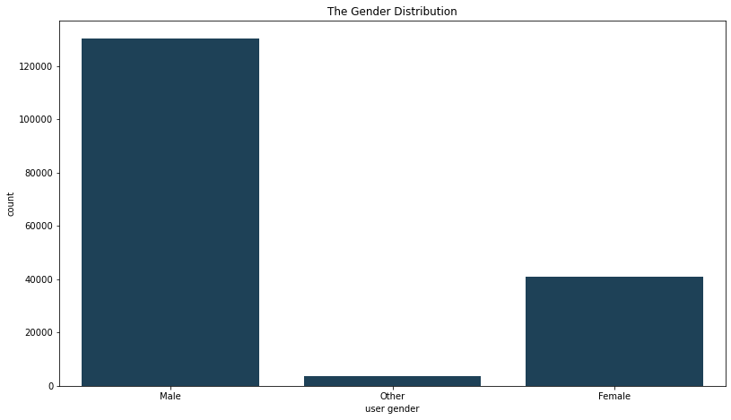

## (Age Distribution)

In the first plot the data was right skewed and shows that the highest number of rides lies between 20 and 30. On the other hand, after adjusting the number of bins and the xlim, it is now clear that the greatest number of rides lies between 30 and 35.

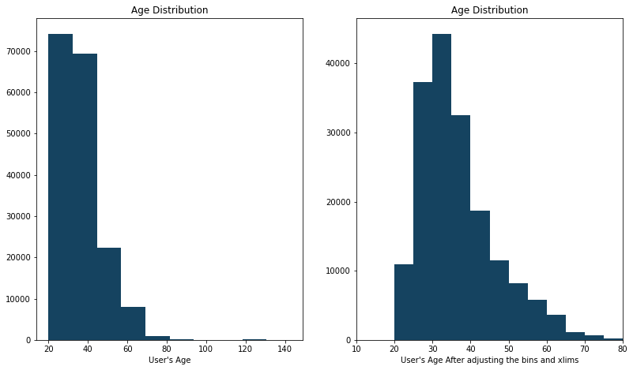

## (Start Hour)

when the largest number of rides occurs?

At 8 AM and 5 PM the greatest number of rides are made.

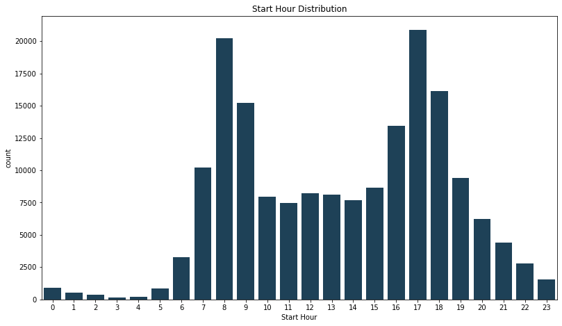

## (Start Day)

when the largest number of rides occurs?

On Thursday the greatest number of rides are made.

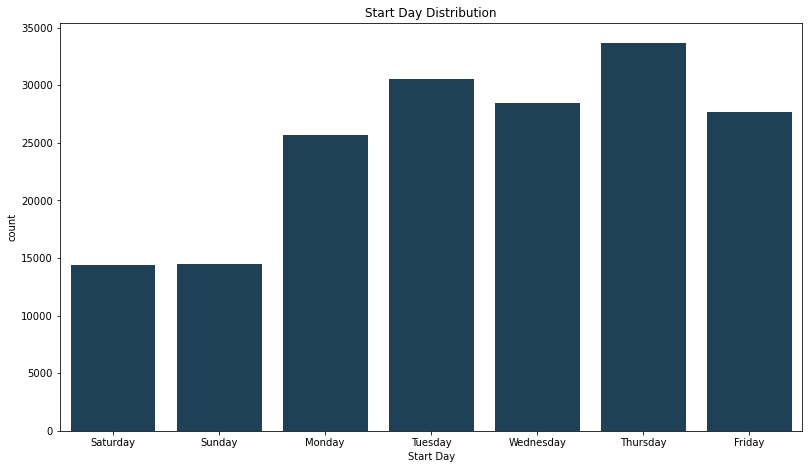

## (Gender and User Type)

which user type that makes the largest number of rides?

The males who are sunscribers make the biggest number of rides

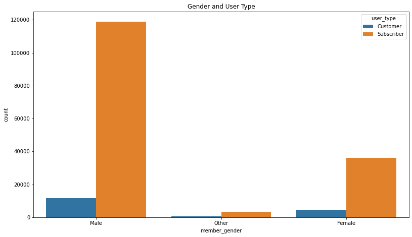